# Analysis of Cyclistic bikes Users: annual members vs. casual riders

2023-11-07

## Objective

Analyze Cyclistic’s ridership data to understand bike use between Annual members and casual riders.

## Executive Summary

- Analysed Cyclistic’s ridership data for the first quarter of 2023 (January to March) to understand Bike use between Annual members and casual riders
- The following insights were uncovered:
  - More *annual members* use the bikes during the weekdays as compared to the week, Bike use by *casual users* is varies within the week
  - *Casual users* generally have a higher trip duration compared to *members*. The number increases sharply on the weekends. The trip duration for *members* is steady on weekdays with a slight increase over the weekend.
  - *Both* customer segments prefer electric bikes. However, *casual riders* prefer docked bikes for longer trip duration.
- Focus on *bike use*, *day of the week* and *bike preference* while designing marketing strategies

## Number of rides by day of the week

- The subscribed members use the bikes more on weekdays as compared to weekends.

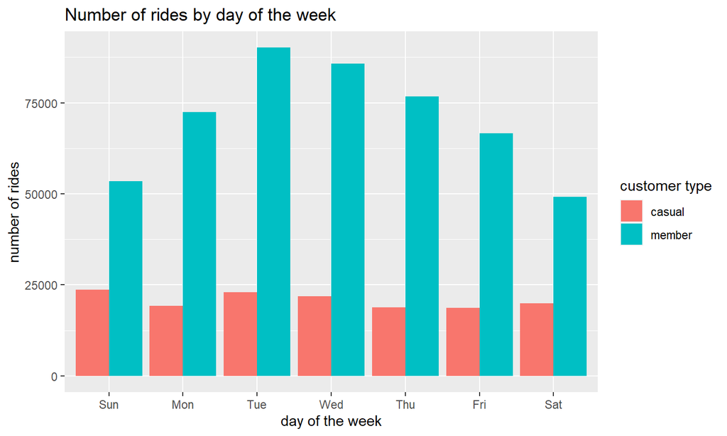

## Average trip duration by customer type

- The average trip duration for casual riders is more than double the average trip duration for members.

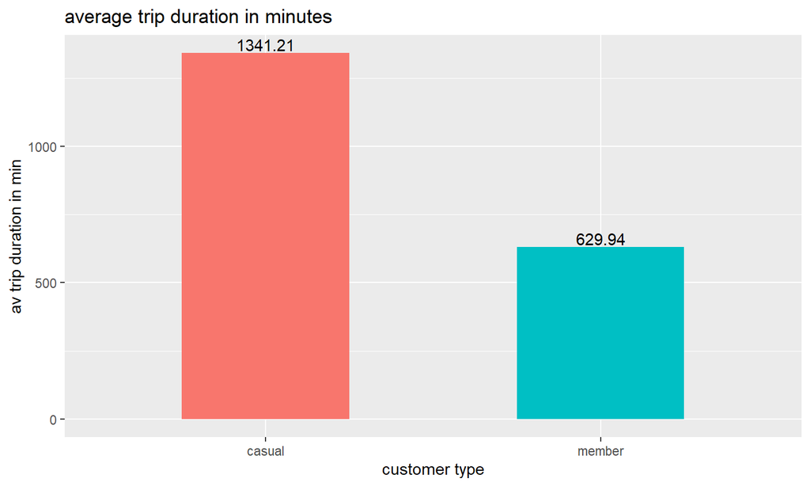

## Average ride duration by day of the week

- Both customer segments have relatively higher ride duration during the weekends
- Casual riders have generally a higher ride duration. this number increases sharply over the weekend.

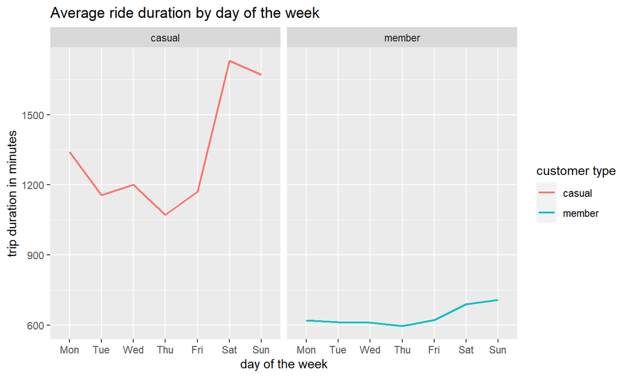

## Bike preference by customer type

- There are no subscribed members that used docked bikes.
- A higher proportion of customers in both segments prefer electric bikes over other bike types.

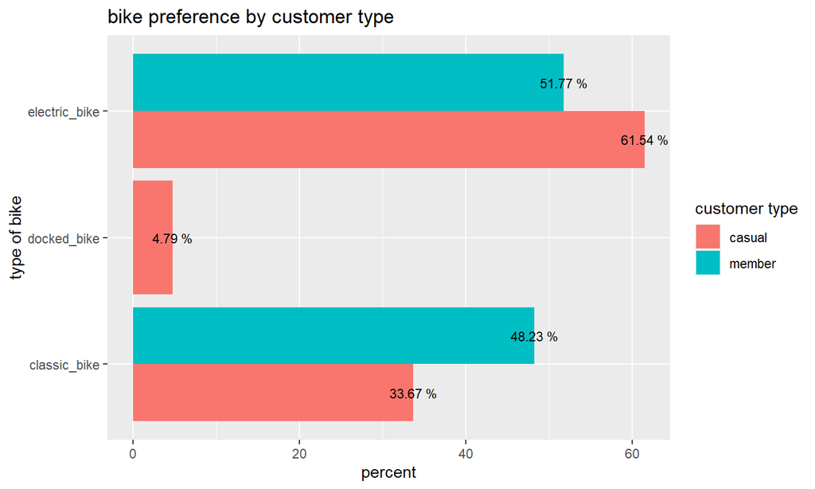

## Average ride duration by bike type

Comparing the average ride duration for each bike type, we notice that docked bikes have a higher ride duration compared to other bike types.

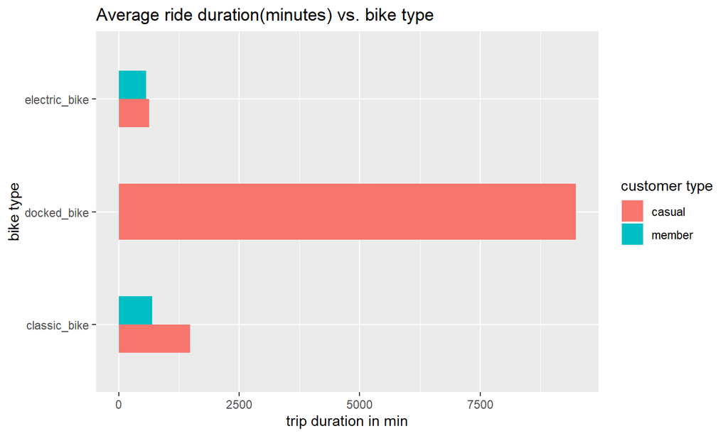

## Next steps

Further analysis needed on

- Trip duration, we have trips that lasts that < 5 seconds
- More data on the use of bikes by the customers
- Additional demographics for analysis e.g. age of users